M.S. Applied Data Science · Syracuse University

# Gabriela *Bermudez*

The data shows the pattern. The story shows the person.

EDUCATION DATA SCIENTIST · STRATEGIC INNOVATOR · HIGHER EDUCATION LEADER

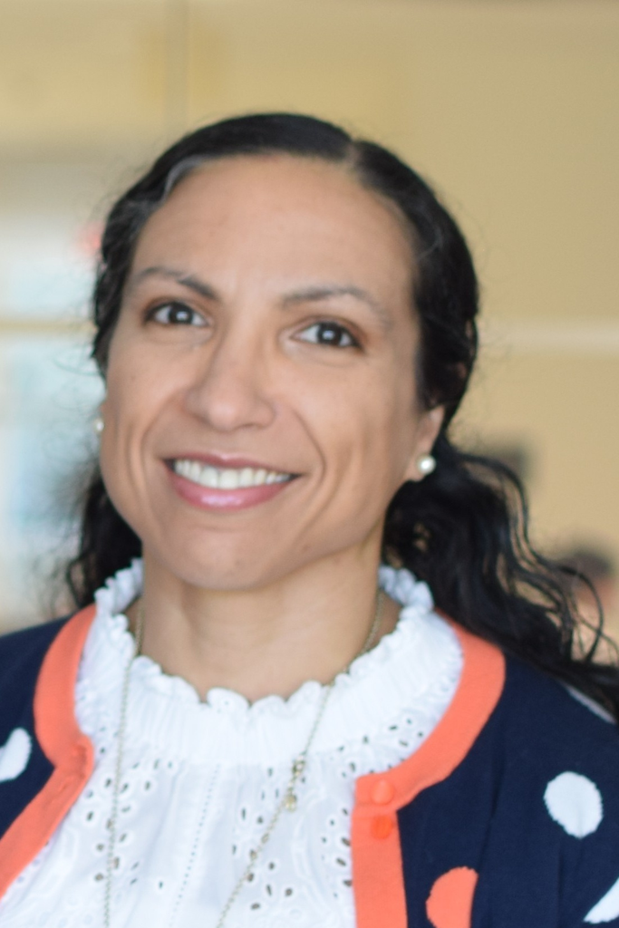

Scroll

About

20

Years in Higher Education

3

Degrees Earned

7+

Portfolio Projects

290+

Students Advised at ECS

## Executive Summary

I am completing a Master of Science in Applied Data Science at Syracuse University's School of Information Studies, in collaboration with the Whitman School of Management. Before enrolling, I spent nearly two decades in higher education student success — advising undergraduate students at Penn State, Miami University, and Syracuse University.

"I didn't leave education to do data science. I brought data science back to it."

I wanted to understand the data behind the patterns I had been observing in students for years, and to develop the analytical tools to turn institutional observation into evidence that drives change.

What I have come to believe: the most important skill in applied data science is not any single method. It is the ability to ask a question that matters, apply rigorous methods honestly, and communicate findings to people who can act on them.

Academic Foundation

## Education

2023–2026

M.S. Applied Data Science

Syracuse University — iSchool & Whitman School of Management

Machine learning, deep learning, text mining, big data analytics, visual analytics, database administration, scripting for data science, and information policy. Python, R, SQL, TensorFlow.

2004–2006

M.S. Public Policy and Management

Carnegie Mellon University

Evidence-based decision-making, program evaluation, and policy analysis.

Marco Delgado Scholar

2000–2004

B.A. International Relations & Spanish Language, Literature and Culture

Syracuse University

Concentration in Foreign Policy and Conflict Resolution.

Professional Vision

## Analytics Should Not Merely Measure — It Should Improve Lives.

"I am at my best when the technical problem and the human problem are the same problem."

My vision is to use data science to build more equitable and effective systems in education and beyond. By combining strategy, empathy, and evidence, I aim to help institutions better understand the people they serve, remove barriers to success, and create pathways where more people can thrive.

Every methodological choice is also an ethical choice. Using SHAP values in the retention model reflects a judgment that interpretability is a form of accountability. Data science is never value-neutral.

I want to be remembered as someone who challenged broken systems with grace and strategy, and who never stopped believing in what was possible.

Portfolio

## 7+ Projects. Five Domains.

Click "View Project" on any card to see the full breakdown — business need, key stats, findings, and attached files.

01

IST 659 · Database Administration · Spring 2024

ECS Student Probation Database

3 data sources 12 research questions FERPA-compliant Oracle DBMS · SQL

3

Data Sources

Oracle · FAFSA · ASPiRe

12

Research Questions

Driving every design decision

5 yrs

Longitudinal Tracking

Retention & graduation outcomes

FERPA

Compliant

Student ID abstraction architecture

Business Need

To create a probationary student database that assesses information, improves students' experiences in ECS, and strengthens the Thriving in ECS probation recovery program. ECS may place any student with a cumulative GPA below 2.0 on academic probation — or if their semester GPA falls below 2.0, or if the student fails to meet other criteria for good academic standing.

What I Built

A multi-phase relational database tracking probation history, advising interactions, demographics, course-level risk factors, and intervention outcomes for ECS students. Drew from three institutional sources: Central Oracle DBMS, FAFSA, and ASPiRe.

Key Finding

Design decisions made early determine what questions can be asked later. Built around 12 specific institutional questions so every entity and relationship was purposeful — not assumed.

Learning Outcome

For years I could see individual students struggling — but I couldn't see the patterns behind them. Building this database taught me that every design decision is a choice about whose story gets told, and how safely.

Project Files

[View Report](https://github.com/GabBermudez/gabbermudez.github.io/blob/main/projects/01-probation-database/3-26%20Group%202%20Final%20Technical%20Report.pdf) [SQL Code](https://gabbermudez.github.io/projects/01-probation-database/SQLQuery_finalv2.sql) [Flow Diagram](https://github.com/GabBermudez/gabbermudez.github.io/blob/main/projects/01-probation-database/Flow%20Diagram.pdf) [Data Model](https://gabbermudez.github.io/projects/01-probation-database/Conceptual_%20DataModel.png)

02

IST 736 · Text Mining · Spring 2024

NLP Text Mining — Thriving in ECS Workshop

26 documentsKMeans k=2VADER 0.430→0.167Python · NLTK

26

Documents

13 Pre · 13 Post workshop

k=2

KMeans Clusters

Separated without labels

0.430

Pre Sentiment

VADER compound score

0.167

Post Sentiment

Grounded, realistic shift

Business Need

In Spring 2024, ECS piloted "Powering Through Academic Recovery" — a mandatory workshop replacing the formal appeal process for students on the highest level of probation. Held January 26, 2024, it was grounded in design thinking: mind mapping, problem framing, prototyping, and articulating NACE career competencies. This project measures whether it actually worked.

What I Built

A text mining pipeline on real pre/post workshop survey responses to determine whether students' language and sentiment shifted after the workshop. KMeans clustering, TF-IDF, PCA, VADER sentiment analysis.

Key Finding

KMeans separated Pre and Post responses without using labels during training — language patterns shifted enough to be distinguishable by content alone. Pre: 'problem,' 'help,' 'plan.' Post: 'mind map,' 'enjoy,' 'connections.' First quantitative analysis ever conducted on this workshop's feedback.

Learning Outcome

I had run this workshop and believed it was working — but believing something and being able to show it are very different things. What surprised me most was that the algorithm confirmed what I had sensed in the room: students weren't just saying different things after the workshop. They were thinking differently.

Project Files

[View Paper](https://github.com/GabBermudez/gabbermudez.github.io/blob/main/projects/02-nlp-workshop/Bermudez_Gabriela_IST_736-HW3v2.pdf) View Notebook [Image 1](https://gabbermudez.github.io/projects/02-nlp-workshop/Picture1.png) [Image 2](https://gabbermudez.github.io/projects/02-nlp-workshop/Picture2.png)

03

IST 652 · Applied Data Science · Fall 2024

EV Adoption & CO₂ Emissions — Global Analysis

4 datasets8 world regions1750–2022Python · pandas · matplotlib

4

Datasets

IEA · Kaggle · Global Carbon

8

World Regions

4 income group breakdowns

272

Years of Data

1750 – 2022

18.5M

Asia EV Sales

Leading globally yet emissions stay high

Business Need

Does EV adoption actually reduce emissions — or does grid composition determine the outcome? Policymakers assuming EV adoption alone drives decarbonization may be missing the bigger picture. This project tests that assumption across 8 world regions and 272 years of data.

What I Built

A multi-source analysis merging IEA Global EV Outlook, Kaggle EV sales data, emissions datasets, and the Global Carbon Budget to examine EV adoption vs. CO₂ emissions across regions and income groups.

Key Finding

Asia leads in EV adoption (18.5M sales) yet emissions remain high — the grid is still coal-dependent. More EVs ≠ fewer emissions without grid decarbonization. Battery Electric Vehicles dominate all powertrain types globally, with exponential growth since 2016.

Learning Outcome

This project taught me to be skeptical of optimistic headlines. Good data science doesn't confirm what we want to believe — it asks harder questions. The data tells a more complicated story than 'EVs are saving the planet.'

Project Files

[View Report](https://github.com/GabBermudez/gabbermudez.github.io/blob/main/projects/03-ev-analysis/IST_652_Alpha_Group_Final_Project_Report.pdf) [View Notebook](https://github.com/GabBermudez/gabbermudez.github.io/blob/main/projects/03-ev-analysis/IST_652_Alpha_Group_Final_Project_FINAL_12_13_24.ipynb) [Image 1](https://gabbermudez.github.io/projects/03-ev-analysis/Picture1.png) [Image 2](https://gabbermudez.github.io/projects/03-ev-analysis/Picture2.png) [Image 3](https://gabbermudez.github.io/projects/03-ev-analysis/Picture3.png) [Image 4](https://gabbermudez.github.io/projects/03-ev-analysis/Picture4.png)

04

IST 707 · Data Analytics · Fall 2024

Predicting High School Student Academic Performance

2,392 students9 methodsR²=0.95Lift=6.73R · caret · randomForest

2,392

Students

Demographics & habits

9

Methods Applied

Rules to Random Forest

0.95

R² Regression

95.42% variance explained

6.73

Top Rule Lift

Directly actionable in advising

Business Need

Student success is shaped by far more than GPA and attendance. As Schreiner (2012) argues, student success encompasses academic achievement, engagement, satisfaction, and personal development. Traditional metrics provide only a partial picture. This study analyzes 2,392 students to identify key predictors and offer actionable insights that extend beyond grades.

What I Built

A full comparison across 9 data mining methods: association rule mining, K-Means and hierarchical clustering, regression, decision trees, Naive Bayes, SVM, kNN, and Random Forest on a dataset of 2,392 high school students.

Key Finding

Absence–GPA correlation: 0.92 — each additional absence = 0.92-point GPA drop. SVM and Random Forest achieved ~78–80% accuracy. Highest-lift rule (6.73): high GPA + very low absences + tutoring → B outcome — directly translatable to advising practice.

Learning Outcome

Twenty years of advising taught me that the students who disappear rarely announce it. This project confirmed what I already knew in my gut — absences matter more than almost anything else — and gave me the statistical language to say it with precision.

Project Files

[View Paper](https://docs.google.com/viewer?url=https://gabbermudez.github.io/projects/04-student-performance/IST%20707-Student%20Performance%20Final%20Projectv3.docx&embedded=false) [R Markdown Code](https://gabbermudez.github.io/projects/04-student-performance/Final-Project-ARM-v6.Rmd) [View Presentation](https://github.com/GabBermudez/gabbermudez.github.io/blob/main/projects/04-student-performance/Student%20Success%20Factors%20Final%20Presentation%20IST%20707%201.pptx) [Chart 1](https://gabbermudez.github.io/projects/04-student-performance/unnamed-chunk-2-3.png) [Chart 2](https://gabbermudez.github.io/projects/04-student-performance/unnamed-chunk-6-1.png) [Chart 3](https://gabbermudez.github.io/projects/04-student-performance/unnamed-chunk-7-1.png)

05

IST 718 · Big Data Analytics · Spring 2025

Thyroid Cancer Risk Analysis

10,558 recordsSMOTEGB 79.73%Python · scikit-learn

10,558

Records

US patient data

79.73%

GB Accuracy

Gradient Boosting

SMOTE

Class Balancing

+ PCA + interaction terms

PCA

Top Predictor Type

Composite features outperformed raw

Business Need

In clinical AI, class imbalance is critical: a model predicting the majority class for every patient may achieve high accuracy while failing to identify the cases that matter most. For thyroid cancer risk, missing a malignant case carries far greater consequences than a false positive. This project addresses how to build a model that is both accurate and trustworthy.

What I Built

A clinical risk classification model on 10,558 US patient records, addressing class imbalance through PCA, SMOTE, class weighting, and interaction terms. Compared Gradient Boosting, SVM, Logistic Regression, and Random Forest.

Key Finding

Gradient Boosting: 79.73% accuracy. SVM: strongest recall for malignant cases — the clinically important metric. PCA-composite features outperformed raw clinical indicators, raising a critical question: a model that is accurate but opaque may not be trustworthy enough for clinical use.

Learning Outcome

The hardest moment in this project was realizing that the most accurate model was also the least explainable. If a physician cannot understand why the model flagged a patient, the model is not truly useful, no matter how high its accuracy. This changed how I think about what it means to build something trustworthy.

Project Files

[View Paper](https://docs.google.com/viewer?url=https://gabbermudez.github.io/projects/05-thyroid-cancer/Group_2_IST_718_Final_Project.docx&embedded=false) [View Notebook](https://github.com/GabBermudez/gabbermudez.github.io/blob/main/projects/05-thyroid-cancer/Group_2_IST_718_Final_Projectv4.ipynb) [View Presentation](https://github.com/GabBermudez/gabbermudez.github.io/blob/main/projects/05-thyroid-cancer/IST-718_Cancer_risk_analysis_PPT_with_Audio%201.pptx)

06

IST 691 · Deep Learning · 2025

Food Image Classification & Anomaly Detection

MobileNetV295.2% accuracy90+ categoriesTensorFlow / Keras

95.2%

Classifier Accuracy

MobileNetV2 transfer learning

90+

Food Categories

Multi-class classification

MSE

Anomaly Metric

Reconstruction error via autoencoder

Hybrid

Architecture

Supervised + unsupervised combined

Business Need

Dietary tracking applications require accurate image classification across hundreds of categories — while also detecting inputs outside the model's training distribution. Standard classifiers fail gracefully when encountering unknown categories. This project addresses both challenges using a hybrid deep learning architecture.

What I Built

A hybrid framework: MobileNetV2 transfer learning classifier (95.2% accuracy on 90+ categories) combined with a convolutional autoencoder for anomaly detection via elevated reconstruction error on out-of-distribution inputs.

Key Finding

The autoencoder, trained only on 'healthy' foods, produced statistically distinguishable reconstruction errors for unknown inputs. Key insight: anomaly detection is portable across domains — in student data, an anomaly might be a sudden drop in LMS logins or a divergent grade trajectory.

Learning Outcome

What I took from this project wasn't really about food. It was about learning to build systems that know what they don't know. The autoencoder flagged images it had never seen before — by recognizing its own uncertainty. I keep thinking about how powerful that would be in student data.

Project Files

[View Paper](https://docs.google.com/viewer?url=https://gabbermudez.github.io/projects/06-food-image/IST%20691%20Final%20Paper_Rev2%20copy.docx&embedded=false) [View Notebook](https://github.com/GabBermudez/gabbermudez.github.io/blob/main/projects/06-food-image/IST_691_Final_Project_v3.ipynb) [Image 1](https://gabbermudez.github.io/projects/06-food-image/Picture1.png) [Image 2](https://gabbermudez.github.io/projects/06-food-image/Picture2.png) [Image 3](https://gabbermudez.github.io/projects/06-food-image/Picture3.png) [Image 4](https://gabbermudez.github.io/projects/06-food-image/Picture4.png)

07

Independent Research Project · In Progress

ECS Student Retention Risk Prediction Model

SHAP valuesLR + Random Forestk-fold CVTableau dashboardNavigate integration

SHAP

Interpretability

Feature-level explanations per student

k-fold

Validation

Cross-validated risk scores

Tableau

Advisor Dashboard

Early alert interface

2

Models

Logistic Regression + Random Forest

Business Need

Advisors in ECS currently rely on reactive outreach — reaching students after they appear in crisis rather than before. No predictive system exists to identify which students are most at risk of leaving before completing their degree. This independent project builds that system: an interpretable retention risk model with an advisor-facing early alert tool.

What I'm Building

Logistic Regression + Random Forest with k-fold cross-validation and SHAP values to produce interpretable risk scores. Variables: GPA, credits, advising visits, financial holds, LMS logins, Pell eligibility, first-gen status, major, probation type.

Key Design Decision

SHAP values make the model actionable: for any student, an advisor can see exactly which features are driving the risk score. A model that cannot explain itself is not useful in practice. The goal is to augment advisor judgment — not replace it.

Learning Outcome

This is the project I came to this program to build. Everything before it was preparation. What I want an advisor to be able to say is not "the model says this student is at risk." I want them to say "I reached out on Tuesday because I saw something shift in their data — and they're still here." That is the version of data science I am trying to build.

Toolkit

## Core Technical Skills

Data Collection & Storage

Oracle DBMS · SQL (ERDs, migrations) · FERPA-compliant architecture · Qualtrics & Formstack · ASPiRe

Project 01 — ECS Probation Database

Natural Language Processing

Python / NLTK · TF-IDF · KMeans · PCA · VADER sentiment · WordNet lemmatization · Apriori rules

Project 02 — NLP Workshop Feedback

Machine Learning & Predictive Modeling

SVM · Random Forest · Gradient Boosting · Naive Bayes · kNN · SMOTE · SHAP · k-fold CV · R (caret, e1071, arules)

Projects 04 & 07

Healthcare & Clinical Analytics

Class imbalance: SMOTE, PCA, interaction terms · Gradient Boosting, SVM · Interpretability vs. accuracy tradeoffs

Project 05 — Thyroid Cancer Risk

Deep Learning

TensorFlow / Keras · MobileNetV2 (transfer learning) · CNNs · Autoencoders · Anomaly detection via reconstruction error

Project 06 — Food Image Classification

Data Analysis & Visualization

Tableau & Power BI · matplotlib · seaborn · ggplot2 · ArcView / GIS · Adobe Creative Suite · Canva

All 7+ projects

Student Analytics Platforms

Navigate · Orange Success · ASPiRe · Institutional data integration (Oracle DBMS, FAFSA, LMS)

Projects 01 & 07

Beyond the Tools

Translating findings for non-technical audiences · Equity-centered analysis · Bilingual: English & Spanish · Collaborative across disciplines

Background

## Professional Experience

Current  
Syracuse, NY

Success Advisor — College of Engineering and Computer Science

Syracuse University

Advises and mentors 290+ ECS undergraduates. Co-created the Thriving in ECS probation recovery program. Initiated and led the student probation data analysis project (Portfolio Project 01).

7 years  
Oxford, OH

Academic Advisor — College of Arts and Science

Miami University

Advised 600+ undergraduates. Digitized petition and degree audit processes. Master Advisor Award 2019. Academic Advising Level A Status 2016–2019.

Earlier  
University Park, PA

Academic Coordinator — Ronald E. McNair Postbaccalaureate Program

Penn State University

Worked with 35 first-generation, low-income, and minority scholars across 13 colleges. Chaired the Instructional Technology Committee. Co-founded the DUS Student Leadership Council.

[figure not shown]